# R mācību vārdnīca

## 6. `aes()` — pasaki, ko attēlot

`aes()` norāda, **kuras tabulas kolonnas tiks attēlotas ar kuriem diagrammas elementiem**.

Piemēram:

```r
ggplot(
  data = dati,
  aes(
    x = gads,
    y = skaits
  )
)
```

nozīmē:

- kolonnas `gads` vērtības nosaka pozīciju uz **horizontālās x ass**;
- kolonnas `skaits` vērtības nosaka pozīciju uz **vertikālās y ass**.

### Biežāk lietotie `aes()` elementi

| `aes()` elements | Ko tas nozīmē? | Piemērs |
| --- | --- | --- |
| `x` | Kura mainīgā vērtības nosaka pozīciju uz horizontālās ass. | `x = gads` |
| `y` | Kura mainīgā vērtības nosaka pozīciju uz vertikālās ass. | `y = skaits` |
| `color` | Kura mainīgā vērtības tiek atšķirtas ar krāsu. | `color = originala_valoda` |
| `fill` | Kura mainīgā vērtības tiek atšķirtas ar laukuma aizpildījuma krāsu. | `fill = originala_valoda` |
| `group` | Kuri novērojumi pieder kopā, piemēram, kuri punkti jāsavieno vienā līnijā. | `group = originala_valoda` |

### Maza piemēra datu kopa

Tālākajās diagrammās izmantojam mazu demonstrācijas datu kopu, lai būtu viegli redzēt, ko dara katrs elements.

```r
library(tidyverse)

piemera_dati <- tibble(
  gads = rep(2021:2024, 3),
  valoda = rep(c("Angļu", "Vācu", "Franču"), each = 4),
  skaits = c(
    80, 92, 110, 125,
    55, 62, 58, 72,
    30, 40, 52, 60
  )
)
```

### `x` un `y` — pozīcija

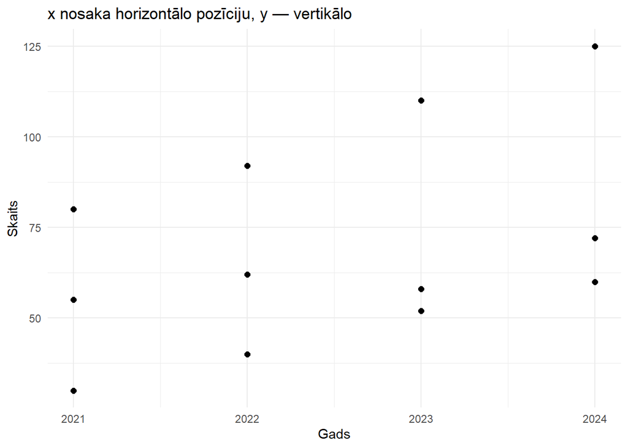

```r
ggplot(
  data = piemera_dati,
  aes(x = gads, y = skaits)
) +
  geom_point(size = 2) +
  labs(
    title = "x nosaka horizontālo pozīciju, y — vertikālo",
    x = "Gads",
    y = "Skaits"
  ) +
  theme_minimal()
```

### `color` — datu kategorijas atšķir ar krāsu

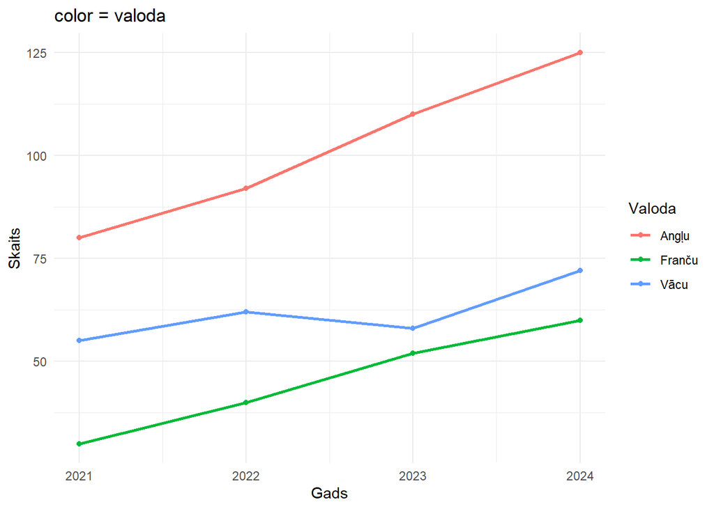

```r
ggplot(
  data = piemera_dati,
  aes(
    x = gads,
    y = skaits,
    color = valoda
  )
) +
  geom_line(linewidth = 1) +
  geom_point() +
  labs(
    title = "color = valoda",
    color = "Valoda",
    x = "Gads",
    y = "Skaits"
  ) +
  theme_minimal()
```

Šeit kolonnas `valoda` vērtības tiek attēlotas ar krāsu. Katra valoda iegūst savu krāsu.

### `fill` — datu kategorijas atšķir ar aizpildījumu

Izveidosim nelielu tabulu ar vienu skaitu katrai valodai:

```r
piemera_kopsavilkums <- piemera_dati |>
  summarise(
    skaits = sum(skaits),
    .by = valoda
  )
```

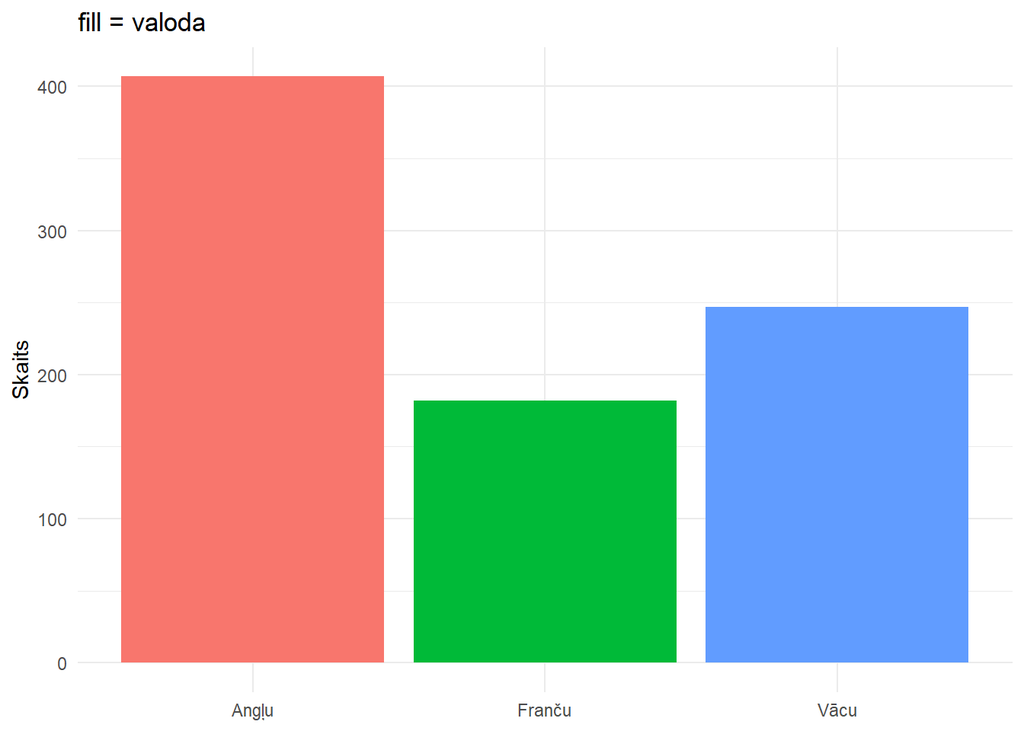

```r
ggplot(
  data = piemera_kopsavilkums,
  aes(
    x = valoda,
    y = skaits,
    fill = valoda
  )
) +
  geom_col(show.legend = FALSE) +
  labs(
    title = "fill = valoda",
    x = NULL,
    y = "Skaits"
  ) +
  theme_minimal()
```

`fill` kontrolē laukuma iekšējo aizpildījumu. Tas ir īpaši raksturīgs joslām un citiem laukuma objektiem.

### `color` un `fill` nav viens un tas pats

Vienkāršoti:

- `color` kontrolē līniju un punktu krāsu, bet objektiem ar laukumu, piemēram, stabiņiem, — **kontūras krāsu**;
- `fill` kontrolē **objekta laukuma aizpildījuma krāsu**, piemēram, stabiņu iekšpusi.

To nozīme ir atkarīga arī no izvēlētās `geom_*()` funkcijas.

### `group` — kuri novērojumi pieder kopā

`group` ir nedaudz citāds nekā `x`, `y`, `color` un `fill`. Tas pats par sevi nenosaka redzamu diagrammas īpašību. `group` pasaka `ggplot2`, **kuri novērojumi pieder kopā**, piemēram, kuri punkti jāsavieno vienā līnijā.

Ja datos ir tikai **viena laika rinda**, `group` nav nepieciešams:

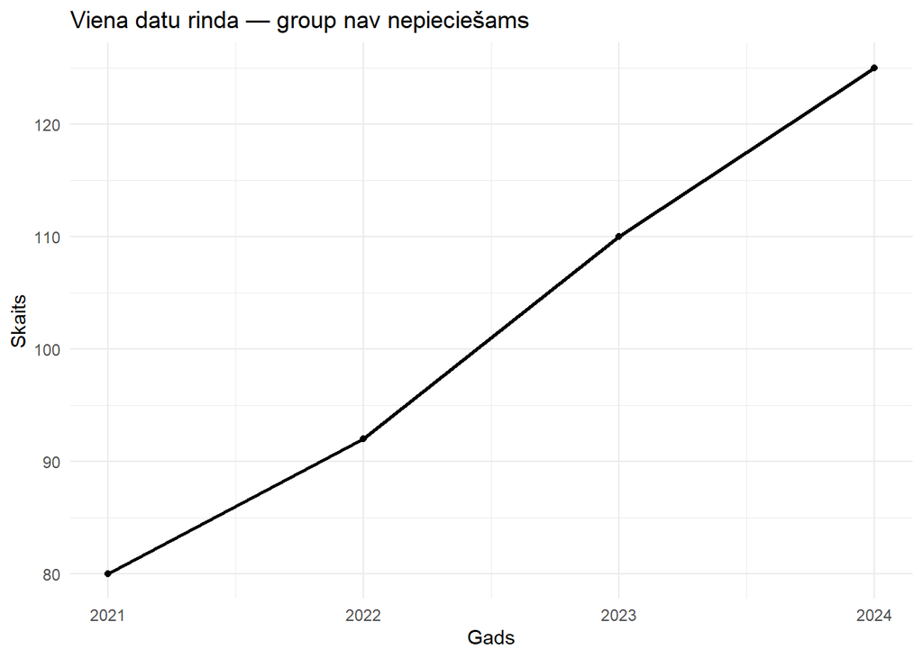

```r
viena_valoda <- piemera_dati |>
  filter(valoda == "Angļu")

ggplot(
  data = viena_valoda,
  aes(x = gads, y = skaits)
) +
  geom_line(linewidth = 1) +
  geom_point() +
  labs(
    title = "Viena datu rinda — group nav nepieciešams",
    x = "Gads",
    y = "Skaits"
  ) +
  theme_minimal()
```

Šeit katram gadam ir viens novērojums, un `ggplot2` var savienot visus punktus vienā līnijā.

#### Kad `group` ir nepieciešams?

Mūsu demonstrācijas datos ir vairākas valodas. Ja gribam katras valodas novērojumus savienot **atsevišķā līnijā**, bet nevēlamies līnijas atšķirt ar krāsu, grupējums jānorāda tieši:

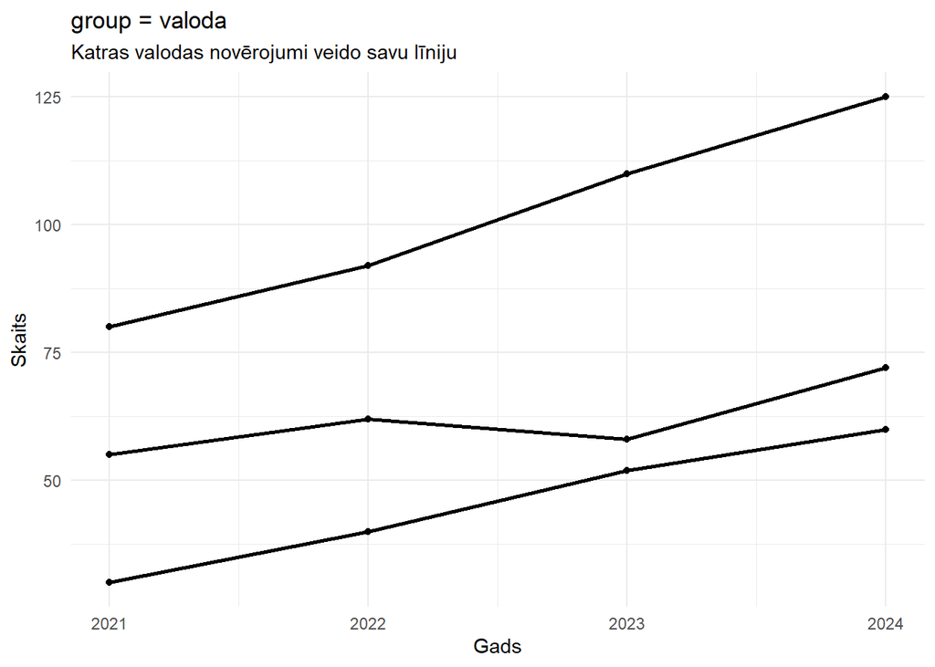

```r
ggplot(
  data = piemera_dati,
  aes(
    x = gads,
    y = skaits,
    group = valoda
  )
) +
  geom_line(linewidth = 1) +
  geom_point() +
  labs(
    title = "group = valoda",
    subtitle = "Katras valodas novērojumi veido savu līniju",
    x = "Gads",
    y = "Skaits"
  ) +
  theme_minimal()
```

`group = valoda` šeit pasaka:

> **Savieno vienā līnijā tos punktus, kuri pieder vienai un tai pašai valodai.**

Visas līnijas izskatās vienādi, jo `group` nosaka grupējumu, nevis to vizuālo izskatu.

#### Ja grupas jau atšķiram ar `color`

Ja valodas attēlojam arī ar dažādām krāsām, pietiek rakstīt:

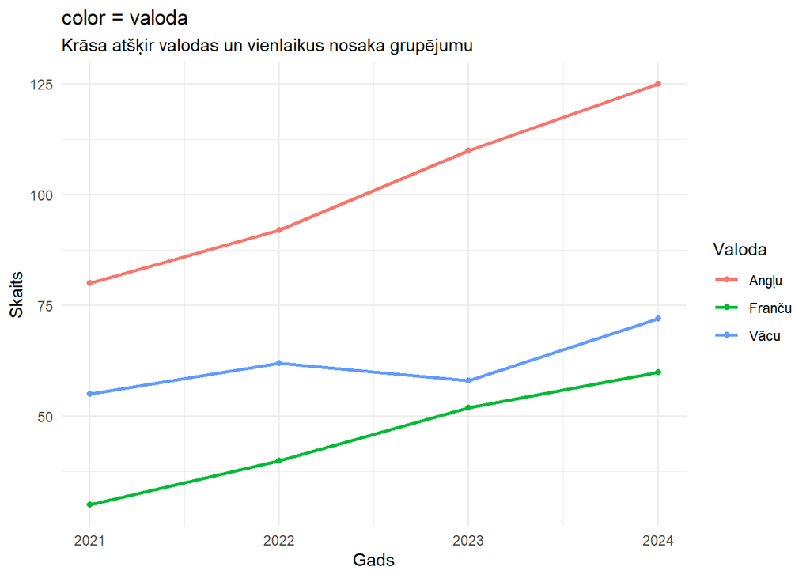

```r
ggplot(
  data = piemera_dati,
  aes(
    x = gads,
    y = skaits,
    color = valoda
  )
) +
  geom_line(linewidth = 1) +
  geom_point() +
  labs(
    title = "color = valoda",
    subtitle = "Krāsa atšķir valodas un vienlaikus nosaka grupējumu",
    color = "Valoda",
    x = "Gads",
    y = "Skaits"
  ) +
  theme_minimal()
```

Šajā gadījumā `ggplot2` no `color = valoda` jau saprot, ka katras valodas novērojumi veido atsevišķu grupu. Tāpēc papildus rakstīt `group = valoda` nav nepieciešams.

> **Praktisks noteikums:** `group` jānorāda tad, ja `ggplot2` no citiem `aes()` elementiem nevar pats saprast, kuri novērojumi veido atsevišķu līniju.

## 7. Datu kodēšana ar krāsu un fiksēta krāsa

Šīs divas konstrukcijas nozīmē atšķirīgas lietas.

### Krāsa attēlo datus

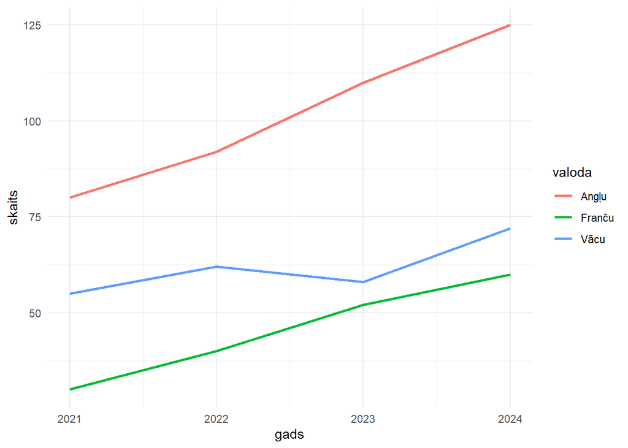

```r
ggplot(
  data = piemera_dati,
  aes(
    x = gads,
    y = skaits,
    color = valoda
  )
) +
  geom_line(linewidth = 1) +
  theme_minimal()
```

`color = valoda` atrodas `aes()` iekšpusē, tāpēc krāsa **attēlo mainīgā `valoda` vērtības**.

### Krāsa ir tikai noformējums

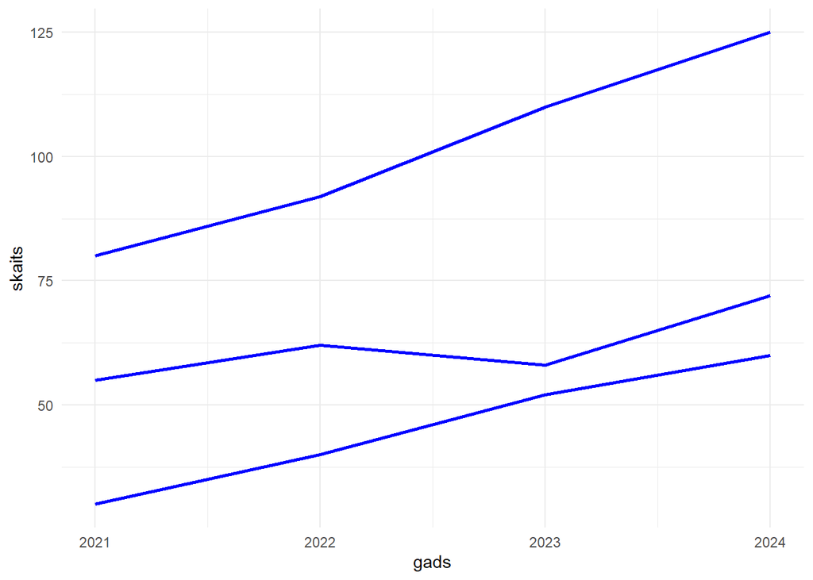

```r
ggplot(
  data = piemera_dati,
  aes(
    x = gads,
    y = skaits,
    group = valoda
  )
) +
  geom_line(color = "blue", linewidth = 1) +
  theme_minimal()
```

`color = "blue"` atrodas ārpus `aes()`, tāpēc krāsa **neattēlo datu mainīgo**. Visas līnijas vienkārši tiek noformētas vienā krāsā.

> **Atceries:** parametrs `aes()` iekšpusē parasti sasaista vizuālo elementu ar datiem. Parametrs ārpus `aes()` parasti nosaka fiksētu noformējumu.

## 8. Izvēlies diagrammas zīmes: `geom_*()`

Pēc tam, kad esam norādījuši, **ko** attēlot, izvēlamies, **ar kādām zīmēm** to attēlot. `geom_*()` funkcijas nosaka diagrammas zīmju veidu — piemēram, joslas, līnijas, punktus vai laukumus.

| Ko gribu parādīt? | Diagrammas zīmes / veids | Piemērs |
| --- | --- | --- |
| Kategoriju lielumu salīdzinājumu | Joslas | `geom_col()` |
| Pārmaiņas laikā | Līnija | `geom_line()` |
| Divu skaitlisku mainīgo saistību (piem., korelāciju) | Punkti / izkliedes diagramma | `geom_point()` |
| Skaitliska mainīgā sadalījumu | Histogramma | `geom_histogram()` |
| Skaitliska mainīgā sadalījumu pa kategorijām | Kastveida diagramma | `geom_boxplot()` |
| Divu kategoriju kombinācijas vai matricu | Laukumi / šūnas | `geom_tile()` |
| Divu mainīgo kombināciju biežumu | Dažāda lieluma punkti | `geom_count()` |

### Horizontāla joslu diagramma

Ja `geom_col()` kategoriju novietojam uz **x ass**, bet skaitlisko vērtību uz **y ass**, iegūstam vertikālus stabiņus:

```r
ggplot(
  data = piemera_kopsavilkums,
  aes(
    x = valoda,
    y = skaits
  )
) +
  geom_col()
```

Ja vēlamies **horizontālas joslas**, mainīgo novietojumu mainām: skaitlisko vērtību liekam uz **x ass**, bet kategoriju — uz **y ass**.

```r
ggplot(
  data = piemera_kopsavilkums,
  aes(
    x = skaits,
    y = valoda
  )
) +
  geom_col()
```

Lai kategorijas būtu arī sakārtotas pēc skaita, izmantojam `reorder()`:

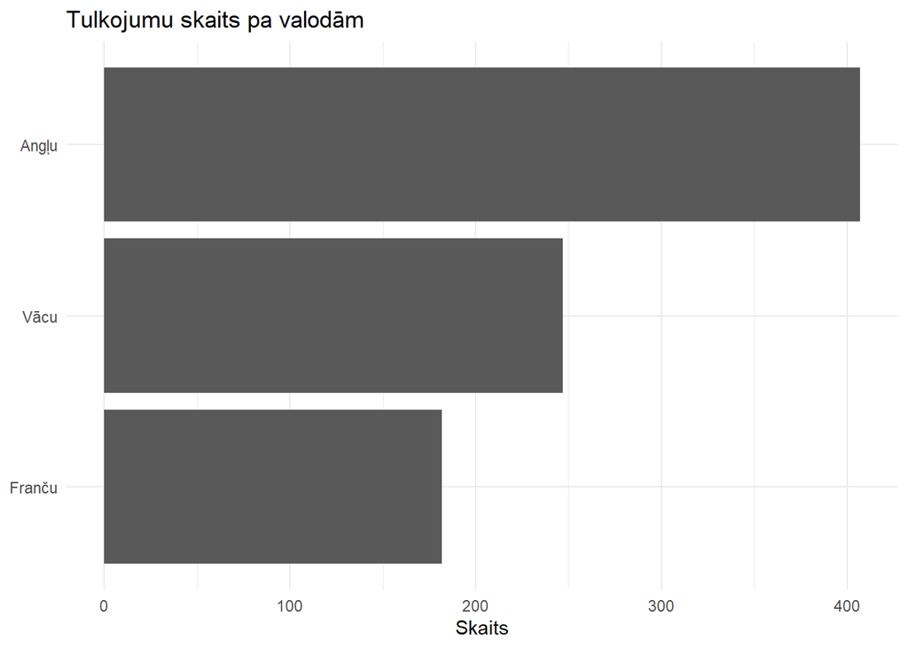

```r
ggplot(
  data = piemera_kopsavilkums,
  aes(
    x = skaits,
    y = reorder(valoda, skaits)
  )
) +
  geom_col() +
  labs(
    title = "Tulkojumu skaits pa valodām",
    x = "Skaits",
    y = NULL
  ) +
  theme_minimal()
```

`reorder(valoda, skaits)` nozīmē: **sakārto `valoda` kategorijas pēc mainīgā `skaits` vērtībām**. `reorder()` nepadara joslas horizontālas — to nosaka tas, ka `skaits` ir uz x ass un `valoda` uz y ass.

Tādējādi **x atbilst horizontālajai asij, bet y — vertikālajai asij**.

### Ko dara `coord_flip()`?

`coord_flip()` apmaina vietām diagrammas x un y koordinātu virzienus. Tas ir bieži sastopams, īpaši vecākos `ggplot2` piemēros, lai vertikālu stabiņu diagrammu pārvērstu horizontālā:

```r
ggplot(
  data = piemera_kopsavilkums,
  aes(
    x = valoda,
    y = skaits
  )
) +
  geom_col() +
  coord_flip()
```

Ja veidojam jaunu diagrammu, horizontālas joslas parasti ir vienkāršāk definēt uzreiz ar `x = skaits` un `y = valoda`. Tomēr `coord_flip()` ir noderīgi pazīt, lai varētu lasīt un pielāgot arī citos materiālos sastopamu `ggplot2` kodu.

## 9. Diagrammas papildu slāņi

### Virsraksti un asu nosaukumi: `labs()`

```r
labs(
  title = "Biežākās tulkojumu oriģinālvalodas",
  subtitle = "Latvijā izdotās tulkotās grāmatas",
  x = "Izdevumu skaits",
  y = NULL
)
```

### Vairākas mazas diagrammas: `facet_wrap()`

`facet_wrap()` sadala vienu vizualizāciju vairākās mazās diagrammās pēc izvēlētās kategorijas.

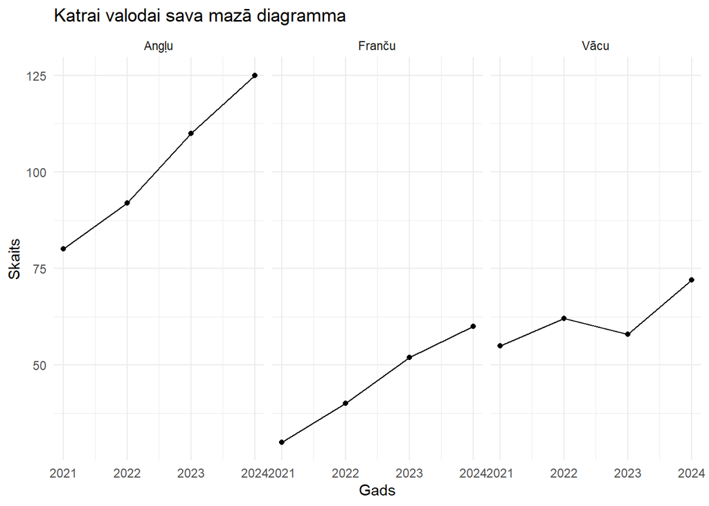

```r
ggplot(
  data = piemera_dati,
  aes(x = gads, y = skaits)
) +
  geom_line() +
  geom_point() +
  facet_wrap(~ valoda) +
  labs(
    title = "Katrai valodai sava mazā diagramma",
    x = "Gads",
    y = "Skaits"
  ) +
  theme_minimal()
```

Facets ir noderīgi, ja vienā diagrammā ir pārāk daudz kategoriju vai līniju un tās kļūst grūti salīdzināt.

### Noformējums: `theme_*()`

`theme_*()` maina diagrammas vizuālo noformējumu, nevis attēlotos datus.

`ggplot2` piedāvā vairākas gatavas tēmas:

```r
theme_minimal()   # minimāls noformējums
theme_classic()   # klasisks noformējums ar asīm, bez režģa
theme_bw()        # melnbalts noformējums
theme_light()     # gaišs noformējums ar režģi
theme_dark()      # tumšs fons
```

Tēmu pievieno diagrammai kā nākamo slāni:

```r
ggplot(dati, aes(x = gads, y = skaits)) +
  geom_line() +
  theme_classic()
```

### Krāsas un krāsu paletes

Ja krāsa **neattēlo datu mainīgo**, bet ir tikai diagrammas noformējums, to norāda ārpus `aes()`:

```r
ggplot(dati, aes(x = skaits, y = valoda)) +
  geom_col(fill = "steelblue")
```

Šajā gadījumā visas joslas ir vienā krāsā. Stabiņiem un joslām `fill` nosaka laukuma aizpildījuma krāsu, bet `color` — kontūras krāsu.

Ja krāsa **attēlo datu kategorijas**, mainīgo norāda `aes()`:

```r
ggplot(dati, aes(
  x = gads,
  y = skaits,
  color = valoda
)) +
  geom_line()
```

`ggplot2` automātiski piešķir kategorijām atšķirīgas krāsas.

#### Gatavas krāsu paletes

Automātisko paleti var nomainīt, piemēram, ar kādu no `viridis` paletēm:

```r
ggplot(dati, aes(
  x = gads,
  y = skaits,
  color = valoda
)) +
  geom_line() +
  scale_color_viridis_d()
```

Joslu diagrammai, kur kategorijas attēlo `fill`, izmanto:

```r
ggplot(dati, aes(
  x = skaits,
  y = valoda,
  fill = valoda
)) +
  geom_col() +
  scale_fill_viridis_d()
```

`_d` nozīmē **discrete** — palete paredzēta kategoriskiem datiem.

#### Paša izvēlētas krāsas

Krāsas var norādīt arī manuāli:

```r
ggplot(dati, aes(
  x = gads,
  y = skaits,
  color = valoda
)) +
  geom_line() +
  scale_color_manual(
    values = c(
      "Angļu" = "steelblue",
      "Vācu" = "darkorange",
      "Franču" = "seagreen"
    )
  )
```

Tādējādi paši nosakām, kura krāsa atbilst katrai kategorijai.

> **Atceries:** ja izmanto `color`, paleti maina ar `scale_color_*()`. Ja izmanto `fill`, paleti maina ar `scale_fill_*()`.

## 10. ggplot2 formulas savas diagrammas veidošanai

### Vispārīgā formula

```r
ggplot(
  data = DATI,
  aes(
    x = X_MAINIGAIS,
    y = Y_MAINIGAIS
  )
) +
  geom_...() +
  labs(
    title = "Virsraksts",
    x = "X ass",
    y = "Y ass"
  ) +
  theme_minimal()
```

### Joslu diagramma

```r
ggplot(
  data = DATI,
  aes(
    x = SKAITS,
    y = KATEGORIJA
  )
) +
  geom_col() +
  labs(
    title = "Virsraksts",
    x = "Skaits",
    y = NULL
  ) +
  theme_minimal()
```

### Laika rinda

```r
ggplot(
  data = DATI,
  aes(
    x = GADS,
    y = SKAITS
  )
) +
  geom_line() +
  labs(
    title = "Virsraksts",
    x = "Gads",
    y = "Skaits"
  ) +
  theme_minimal()
```

### Vairākas kategorijas vienā laika rindā

```r
ggplot(
  data = DATI,
  aes(
    x = GADS,
    y = SKAITS,
    color = KATEGORIJA
  )
) +
  geom_line() +
  labs(
    title = "Virsraksts",
    color = "Kategorija"
  ) +
  theme_minimal()
```

### Small multiples ar `facet_wrap()`

```r
ggplot(
  data = DATI,
  aes(
    x = GADS,
    y = SKAITS
  )
) +
  geom_line() +
  facet_wrap(~ KATEGORIJA) +
  theme_minimal()
```

## 11. Kā sākt veidot savu diagrammu?

Pirms raksti kodu, secīgi pajautā:

1. **Ko es gribu noskaidrot?**
2. **Kāda tabula man tam ir vajadzīga?**
3. **Kurš mainīgais būs uz x ass?**
4. **Kurš mainīgais būs uz y ass?**
5. **Vai kādu kategoriju vajag attēlot ar krāsu vai aizpildījumu?**
6. **Kāda diagrammas zīme vislabāk parāda šo attiecību — josla, līnija vai punkts?**
7. **Vai kategoriju ir tik daudz, ka noderētu `facet_wrap()`?**
8. **Kādi virsraksti un asu nosaukumi palīdzēs diagrammu saprast?**

> **Galvenais princips:** vispirms formulē jautājumu un sagatavo vajadzīgos datus; tikai pēc tam izvēlies vizualizācijas formu.

Šī vārdnīca ir ievadnodarbības atbalsta materiāls, nevis pilna R vai ggplot2 rokasgrāmata.